# Practical ML Project

jove

## Introduction

This is the report on the Course Project of Paractical Machine Learning Course. The goal of the project is, based on the Weight lifting Exercise Dataset (from the [Human Activity Recognition programme](http://groupware.les.inf.puc-rio.br/har)), to “predict the manner in which they did the exercise”, i.e. how well the weight lifting activity was perfomred by the wearer.

## Getting the data

Firstly, the training and testing data set are loaded from given URLs.

```r
trainUrl <- "http://d396qusza40orc.cloudfront.net/predmachlearn/pml-training.csv"
testUrl <- "http://d396qusza40orc.cloudfront.net/predmachlearn/pml-testing.csv"

df_training <- read.csv(file=trainUrl, na.strings=c("NA",""), header=TRUE)
df_testing <- read.csv(file=testUrl, na.strings=c("NA",""), header=TRUE)
```

## preProcess

Observing that there are many columns within lot of NAs that do not contribute the prediction model, these columns are eliminated.

```r
set.seed(12345)
#count the number of NAs in each col
countNA <- as.vector(apply(df_training, 2, function (x) sum(is.na(x))))
# set elimation threshold
th_NA <- round(nrow(df_training)*0.9)
delete_idx <- which(countNA >=th_NA)
train_V1 <- df_training[,-delete_idx]
# remove the 1st & columns as they are unrelated to prediction
train_V2 <- train_V1[,8:dim(train_V1)[2]]

# perform the same activities on testing set
countNA <- as.vector(apply(df_testing, 2, function (x) sum(is.na(x))))
th_NA <- round(nrow(df_testing)*0.9)
delete_idx <- which(countNA >=th_NA)
test_V1 <- df_testing[,-delete_idx]
test_V2 <- test_V1[,8:dim(train_V1)[2]]
rm(train_V1,test_V1)

# check whether the two sets have the same variables
identical(colnames(test_V2[,-53]),colnames(train_V2[,-53]))
```

```
## [1] TRUE
```

Before building the prediction model, the cleaned training set is divided into traiing subset and cross validation subset.

```r
library(caret)
idx <- createDataPartition(train_V2$classe, p=0.7, list=FALSE)
trainDf <- train_V2[idx,]
cvDf <- train_V2[-idx,]
```

## Using ML algorithms for prediction

Here we test two ML agorithm for prediction: decision tree and random forest. The one with higher accuracy will be choosen as our finalprediction model.

### First Predicion Model: Decision Tree

```r
library(caret)
set.seed(1234)
modFit1 <- train(classe ~., method="rpart", data=trainDf)
```

```r
#print(modFit$finalModel)
# plot tree
library(rattle)
Sys.setlocale("LC_TIME", "C")
```

```
## [1] "C"
```

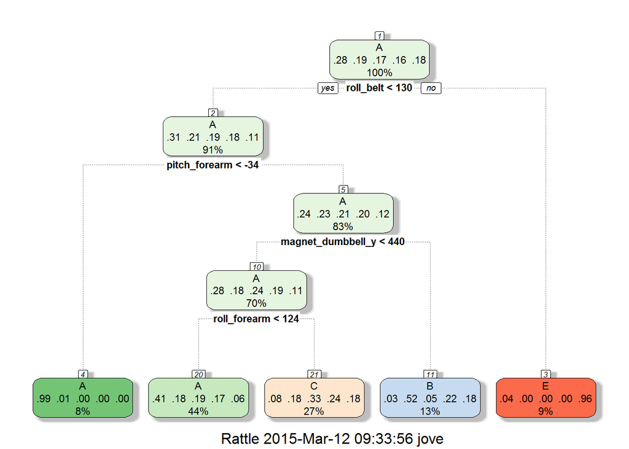

```r
fancyRpartPlot(modFit1$finalModel)
```

Now apply the model on the cross validation dataset.

```r
predcv1 <- predict(modFit1,cvDf)
confusionMatrix(predcv1, cvDf$classe)
```

```
## Confusion Matrix and Statistics
##
##           Reference
## Prediction    A    B    C    D    E
##          A 1494  470  467  438  141
##          B   21  380   29  184  147
##          C  128  289  530  342  277
##          D    0    0    0    0    0
##          E   31    0    0    0  517
##
## Overall Statistics
##
##                Accuracy : 0.4963
##                  95% CI : (0.4835, 0.5092)
##     No Information Rate : 0.2845
##     P-Value [Acc > NIR] : < 2.2e-16
##
##                   Kappa : 0.3425
##  Mcnemar's Test P-Value : NA
##
## Statistics by Class:
##
##                      Class: A Class: B Class: C Class: D Class: E
## Sensitivity            0.8925  0.33363  0.51657   0.0000  0.47782
## Specificity            0.6400  0.91972  0.78679   1.0000  0.99355
## Pos Pred Value         0.4963  0.49934  0.33844      NaN  0.94343
## Neg Pred Value         0.9374  0.85187  0.88516   0.8362  0.89414
## Prevalence             0.2845  0.19354  0.17434   0.1638  0.18386
## Detection Rate         0.2539  0.06457  0.09006   0.0000  0.08785
## Detection Prevalence   0.5115  0.12931  0.26610   0.0000  0.09312
## Balanced Accuracy      0.7662  0.62667  0.65168   0.5000  0.73568
```

### Second Predicion Model: Random Forest

```r
library(randomForest)
modFit2 <- randomForest(classe ~. , data=trainDf)
# check cross validation
predcv2 <- predict(modFit2,cvDf)
confusionMatrix(predcv2, cvDf$classe)
```

```
## Confusion Matrix and Statistics
##
##           Reference
## Prediction    A    B    C    D    E
##          A 1673   10    0    0    0
##          B    1 1125   11    0    0
##          C    0    4 1015   14    0
##          D    0    0    0  950    5
##          E    0    0    0    0 1077
##
## Overall Statistics
##
##                Accuracy : 0.9924
##                  95% CI : (0.9898, 0.9944)
##     No Information Rate : 0.2845
##     P-Value [Acc > NIR] : < 2.2e-16
##
##                   Kappa : 0.9903
##  Mcnemar's Test P-Value : NA
##
## Statistics by Class:
##
##                      Class: A Class: B Class: C Class: D Class: E
## Sensitivity            0.9994   0.9877   0.9893   0.9855   0.9954
## Specificity            0.9976   0.9975   0.9963   0.9990   1.0000
## Pos Pred Value         0.9941   0.9894   0.9826   0.9948   1.0000
## Neg Pred Value         0.9998   0.9971   0.9977   0.9972   0.9990
## Prevalence             0.2845   0.1935   0.1743   0.1638   0.1839
## Detection Rate         0.2843   0.1912   0.1725   0.1614   0.1830
## Detection Prevalence   0.2860   0.1932   0.1755   0.1623   0.1830
## Balanced Accuracy      0.9985   0.9926   0.9928   0.9922   0.9977
```

### Generating files for Submission

```r
# apply our final model on testing dataset
predTest <- predict(modFit2, test_V2)
predTest
```

```
##  1  2  3  4  5  6  7  8  9 10 11 12 13 14 15 16 17 18 19 20
##  B  A  B  A  A  E  D  B  A  A  B  C  B  A  E  E  A  B  B  B
## Levels: A B C D E
```

```r
# write files for submission
pml_write_files = function(x){
  n = length(x)
  for(i in 1:n){
    filename = paste0("problem_id_",i,".txt")
    write.table(x[i],file=filename,quote=FALSE,row.names=FALSE,col.names=FALSE)
  }
}

pml_write_files(predTest)
```